# Background context

This is a report inspired by the Kopi.co (https://thekopi.co/about/)'s report on Singapore's Members of Parliament, titled "How Active Are Your MPs in Parliament? Exploring MPs’ Attendance and Speaking Count". Kopi's report included two tables containing the count of attendance and speaking during parliament sitting for all MPs.

However, the original table presented by the Kopi is a bit hard to comprehend. Therefore, I have done some exploration based on the data provided by the Kopi.

I have not verified if the attendance and speaking counts are correct. I did however, found that one of the MPs profile was wrongly recorded. Assuming all counts are accurate, we might still underestimate the average performance of PAP here. The current cabinet members (including PM Lee) did not record any speaking counts. But I'm unsure of the reasons.

The dashboard here reflects the key findings in my report. For more detail breakdown, including the full table reports, please refer to section: Overall

Original report and data source: https://thekopi.co/2020/06/23/singapore-parliament-performance/

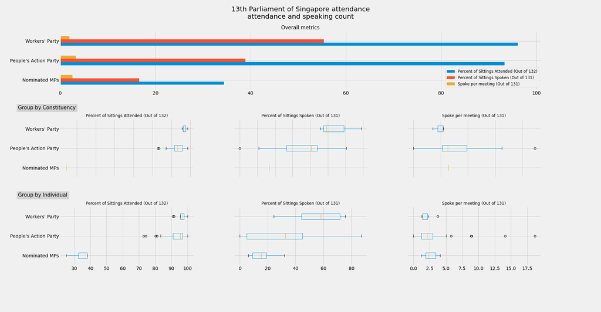

# Library

```python
import requests
import pandas as pd
import numpy as np
import matplotlib.pyplot as plt
plt.style.use('fivethirtyeight')
```

# Data cleaning

The present Thirteenth Parliament has 100 MPs, consisting of 88 elected MPs, 3 Non-Constituency MPs (NCMPs) and 9 Nominated MPs (NMPs)\

There are a total of 82 PAP, 9 WP and 9 NMP

https://www.parliament.gov.sg/about-us/structure/members-of-parliament \ https://en.wikipedia.org/wiki/Parliament_of_Singapore

We will compare the entries in the Kopi with wikipedia page to determine if the entries in the Kopi is correct.

## Load data

Loading data from the Kopi: https://thekopi.co/2020/06/23/singapore-parliament-performance/ \ and wikipedia page: https://en.wikipedia.org/wiki/List_of_members_of_the_13th_Parliament_of_Singapore

```python
url = "https://thekopi.co/2020/06/23/singapore-parliament-performance/"
page = requests.get(url)
content = pd.read_html(page.content)
attendance = content[0]
speaking = content[1]
attendance = attendance[[
    'Party', 'Constituency', 'Name', 'Number of Sittings Attended (Out of 132)'
]]
```

```python
mp_wiki = "https://en.wikipedia.org/wiki/List_of_members_of_the_13th_Parliament_of_Singapore"
mp_page = requests.get(mp_wiki)
mp_contet = pd.read_html(mp_page.content)
mp_names = mp_contet[1]
non_constituency_mp = mp_contet[2]
nmp_names = mp_contet[3]
```

## First look at data

#### Let's check if the entries at wiki page are correct

```python
mp_names.head()
```

|  | Constituency | Party | Party.1 | Name | Portrait | Date of birth(Age) | Ref |
| --- | --- | --- | --- | --- | --- | --- | --- |
| 0 | AljuniedGRC | NaN | WP | Chen Show Mao | NaN | (59 years, 138 days) | [8] |
| 1 | AljuniedGRC | NaN | WP | Sylvia Lim | NaN | (55 years, 87 days) | [9] |
| 2 | AljuniedGRC | NaN | WP | Low Thia Khiang | NaN | (63 years, 292 days) | [10][11] |
| 3 | AljuniedGRC | NaN | WP | Muhamad Faisal bin Abdul Manap | – | (45 years, 17 days) | [12] |
| 4 | AljuniedGRC | NaN | WP | Pritam Singh | NaN | (43 years, 326 days) | [13] |

```python
non_constituency_mp.head()
```

|  | Name | Portrait | Date of birth(Age) | Party | Party.1 | Ref |
| --- | --- | --- | --- | --- | --- | --- |
| 0 | Daniel Goh Pei Siong A | – | 1973(46–47 years) | NaN | Workers' Party | [125] |
| 1 | Leon Perera | – | 1970(49–50 years) | NaN | Workers' Party | [126] |
| 2 | Dennis Tan Lip Fong | – | 1970(49–50 years) | NaN | Workers' Party | [127] |

```python
nmp_names.head()
```

|  | Name | Date of birth(Age) | Ref |
| --- | --- | --- | --- |
| 0 | Azmoon Ahmad | 1962(57–58 years) | [130] |
| 1 | Chia Yong Yong | 10 October 1962(57 years, 257 days) | [131] |
| 2 | Thomas Chua Kee Seng | 1 November 1954(65 years, 235 days) | [132] |
| 3 | Ganesh Rajaram | 1967(52–53 years) | [133] |
| 4 | Kok Heng Leun | 1966(53–54 years) | [134] |

Let's standardise the Non constituency MP by changing their party name into WP (the naming used in mp_names)

```python
non_constituency_mp['Party.1'] = "WP"
```

Let's standardise the NMPs by including a party name

```python
nmp_names['Party.1'] = "Nominated MP"
```

Let's inspect the data

```python
print('Number of')
print('MP: {}\nNon costituency MP: {}\nNMP: {}'\
        .format(mp_names.shape[0], non_constituency_mp.shape[0], nmp_names.shape[0]))
```

```
Number of
MP: 89
Non costituency MP: 3
NMP: 9
```

```python
(mp_names['Name'] == 'Seat Vacant').sum()
```

```
1
```

There is one empty seat as Halimah Yacob step down as MP\ https://www.straitstimes.com/politics/halimah-yacob-steps-down-as-speaker-and-mp-resigns-from-pap-to-run-for-president

```python
#let's drop the row with vacant seats
mp_names = mp_names[~(mp_names['Name'] == 'Seat Vacant')]
```

```python
print('Number of')
print('MP: {}\nNon costituency MP: {}\nNMP: {}'\
        .format(mp_names.shape[0], non_constituency_mp.shape[0], nmp_names.shape[0]))
```

```
Number of
MP: 88
Non costituency MP: 3
NMP: 9
```

Now we have the expected numbers, let's combine the records

```python
sg_parliament = pd.concat([mp_names, non_constituency_mp, nmp_names], axis=0).drop(['Party','Portrait','Ref'], axis=1)
```

```python
sg_parliament.head()
```

|  | Constituency | Party.1 | Name | Date of birth(Age) |
| --- | --- | --- | --- | --- |
| 0 | AljuniedGRC | WP | Chen Show Mao | (59 years, 138 days) |
| 1 | AljuniedGRC | WP | Sylvia Lim | (55 years, 87 days) |
| 2 | AljuniedGRC | WP | Low Thia Khiang | (63 years, 292 days) |
| 3 | AljuniedGRC | WP | Muhamad Faisal bin Abdul Manap | (45 years, 17 days) |
| 4 | AljuniedGRC | WP | Pritam Singh | (43 years, 326 days) |

#### Let's check if the entries at Kopi are correct

## Clean up names

Let's clean up the names first

```python
speaking['Name'] = speaking['Name'].str.replace('^([A-Z]\w+) ','',regex=True).\
                    str.replace('^([A-Z][a-z]+) ','',regex=True).str.title().str.strip()
attendance['Name'] = attendance['Name'].str.replace('^([A-Z]\w+) ','',regex=True).\
                    str.replace('^([A-Z][a-z]+) ','',regex=True).str.title().str.strip()
```

```python
attendance.head()
```

|  | Party | Constituency | Name | Number of Sittings Attended (Out of 132) |
| --- | --- | --- | --- | --- |
| 0 | Workers' Party | Aljunied GRC | Low Thia Khiang | 127 |
| 1 | Workers' Party | Aljunied GRC | Pritam Singh | 129 |
| 2 | People's Action Party | Holland-Bukit Timah GRC | Christopher De Souza | 132 |
| 3 | People's Action Party | Jalan Besar GRC | Denise Phua Lay Peng | 132 |
| 4 | People's Action Party | Nee Soon GRC | Louis Ng Kok Kwang | 132 |

```python
speaking.head()
```

|  | Party | Constituency | Name | Number of Sittings Spoken (Out of 131) |
| --- | --- | --- | --- | --- |
| 0 | People's Action Party | Nee Soon GRC | Louis Ng Kok Kwang | 114 |
| 1 | Workers' Party | Non-Constituency MPs | Leon Perera | 99 |
| 2 | Workers' Party | Non-Constituency MPs | Dennis Tan Lip Fong | 96 |
| 3 | Workers' Party | Aljunied GRC | Pritam Singh | 94 |
| 4 | People's Action Party | Nee Soon GRC | Lee Bee Wah | 92 |

## Verify data accuracy

From the Kopi:

```python
attendance.groupby('Party').count()
```

| Party | Constituency | Name | Number of Sittings Attended (Out of 132) |
| --- | --- | --- | --- |
| Nominated MPs | 9 | 9 | 9 |
| People's Action Party | 82 | 82 | 82 |
| Workers' Party | 9 | 9 | 9 |

```python
speaking.groupby('Party').count()
```

[output not shown]

From wikipedia:

```python
sg_parliament.groupby('Party.1')[['Name']].count()
```

| Party.1 | Name |
| --- | --- |
| Nominated MP | 9 |
| PAP | 82 |
| WP | 9 |

```python
attendance[attendance['Party'] == "Nominated MPs"].sort_values('Name')
```

|  | Party | Constituency | Name | Number of Sittings Attended (Out of 132) |
| --- | --- | --- | --- | --- |
| 93 | Nominated MPs | Nominated MPs | Anthea Ong | 50 |
| 91 | Nominated MPs | Nominated MPs | Arasu Duraisamy | 50 |
| 98 | Nominated MPs | Nominated MPs | Douglas Foo | 39 |
| 95 | Nominated MPs | Nominated MPs | Dr Walter Theseira | 49 |
| 97 | Nominated MPs | Nominated MPs | Irene Quay Siew Ching | 43 |
| 96 | Nominated MPs | Nominated MPs | Lim Sun Sun | 46 |
| 92 | Nominated MPs | Nominated MPs | Mohamed Irshad | 50 |
| 94 | Nominated MPs | Nominated MPs | Terence Ho Wee San | 49 |
| 99 | Nominated MPs | Nominated MPs | Yip Pin Xiu | 33 |

```python
speaking[speaking['Party'] == "Nominated MPs"].sort_values('Name')
```

|  | Party | Constituency | Name | Number of Sittings Spoken (Out of 131) |
| --- | --- | --- | --- | --- |
| 51 | Nominated MPs | Nominated MPs | Anthea Ong | 42 |
| 75 | Nominated MPs | Nominated MPs | Arasu Duraisamy | 12 |
| 76 | Nominated MPs | Nominated MPs | Douglas Foo | 12 |
| 53 | Nominated MPs | Nominated MPs | Dr Walter Theseira | 41 |
| 68 | Nominated MPs | Nominated MPs | Irene Quay Siew Ching | 22 |
| 70 | Nominated MPs | Nominated MPs | Lim Sun Sun | 20 |
| 65 | Nominated MPs | Nominated MPs | Mohamed Irshad | 25 |
| 74 | Nominated MPs | Nominated MPs | Terence Ho Wee San | 14 |
| 78 | Nominated MPs | Nominated MPs | Yip Pin Xiu | 8 |

Let's correct Ms FOO MEE HAR's entry

```python
speaking.loc[speaking['Name'] == 'Foo Mee Har', ['Party', 'Constituency']] = [
    "People's Action Party", "West Coast GRC"
]
```

```python
speaking.groupby('Party').count()
```

| Party | Constituency | Name | Number of Sittings Spoken (Out of 131) |
| --- | --- | --- | --- |
| Nominated MPs | 9 | 9 | 9 |
| People's Action Party | 62 | 62 | 62 |
| Workers' Party | 9 | 9 | 9 |

## Converting to percentage

We are more interested in the relative terms. For example, out of the total sittings, how many sittings did individual attend?\ Therefore, we will compute the percentage terms for all dataframes.\ We will keep only 2 decimal points for a neater presentation.

```python
attendance['Percent of Sittings Attended (Out of 132)'] = (attendance['Number of Sittings Attended (Out of 132)']\
                                                            /132 * 100).round(2)
```

```python
attendance.head()
```

|  | Party | Constituency | Name | Number of Sittings Attended (Out of 132) | Percent of Sittings Attended (Out of 132) |
| --- | --- | --- | --- | --- | --- |
| 0 | Workers' Party | Aljunied GRC | Low Thia Khiang | 127 | 96.21 |
| 1 | Workers' Party | Aljunied GRC | Pritam Singh | 129 | 97.73 |
| 2 | People's Action Party | Holland-Bukit Timah GRC | Christopher De Souza | 132 | 100.00 |
| 3 | People's Action Party | Jalan Besar GRC | Denise Phua Lay Peng | 132 | 100.00 |
| 4 | People's Action Party | Nee Soon GRC | Louis Ng Kok Kwang | 132 | 100.00 |

```python
speaking['Percent of Sittings Spoken (Out of 131)'] = (speaking['Number of Sittings Spoken (Out of 131)']\
                                                       /131*100).round(2)
```

```python
speaking.head()
```

|  | Party | Constituency | Name | Number of Sittings Spoken (Out of 131) | Percent of Sittings Spoken (Out of 131) |
| --- | --- | --- | --- | --- | --- |
| 0 | People's Action Party | Nee Soon GRC | Louis Ng Kok Kwang | 114 | 87.02 |
| 1 | Workers' Party | Non-Constituency MPs | Leon Perera | 99 | 75.57 |
| 2 | Workers' Party | Non-Constituency MPs | Dennis Tan Lip Fong | 96 | 73.28 |
| 3 | Workers' Party | Aljunied GRC | Pritam Singh | 94 | 71.76 |
| 4 | People's Action Party | Nee Soon GRC | Lee Bee Wah | 92 | 70.23 |

# Data visualisation

## Attendance

### Attendance by Party

```python
(attendance.groupby('Party')[['Percent of Sittings Attended (Out of 132)']].mean()).\
    sort_values(['Percent of Sittings Attended (Out of 132)'],ascending=False).round(2)
```

| Party | Percent of Sittings Attended (Out of 132) |
| --- | --- |
| Workers' Party | 96.13 |
| People's Action Party | 93.28 |
| Nominated MPs | 34.43 |

### Attendance by Constituency

|  | count | mean | std | min | 25% | 50% | 75% | max |
| --- | --- | --- | --- | --- | --- | --- | --- | --- |
| Percent of Sittings Attended (Out of 132) | 31.0 | 91.464194 | 11.275163 | 34.43 | 91.51 | 93.94 | 96.275 | 98.48 |

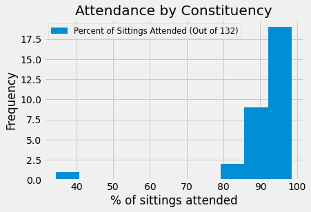

```python
(attendance.groupby(['Constituency','Party'])[['Percent of Sittings Attended (Out of 132)']].mean())\
                    .sort_values('Percent of Sittings Attended (Out of 132)',ascending=False).round(2).\
                    plot.hist(bins=10)
plt.xlabel('% of sittings attended'), plt.title('Attendance by Constituency')
plt.legend(fontsize='small')

(attendance.groupby(['Constituency','Party'])[['Percent of Sittings Attended (Out of 132)']].mean())\
                    .sort_values('Percent of Sittings Attended (Out of 132)',ascending=False).round(2).\
                    describe().T
```

Highest attendance rate

```python
(attendance.groupby(['Constituency','Party'])[['Percent of Sittings Attended (Out of 132)']].mean())\
                    .sort_values('Percent of Sittings Attended (Out of 132)',ascending=False).round(2).head()
```

| Constituency | Party | Percent of Sittings Attended (Out of 132) |
| --- | --- | --- |
| Hougang SMC | Workers' Party | 98.48 |
| Mountbatten SMC | People's Action Party | 98.48 |
| Marsiling-Yew Tee GRC | People's Action Party | 97.98 |
| Tanjong Pagar GRC | People's Action Party | 97.27 |
| Potong Pasir SMC | People's Action Party | 96.97 |

Lowest attendance rate

```python
(attendance.groupby(['Constituency','Party'])[['Percent of Sittings Attended (Out of 132)']].mean())\
                    .sort_values('Percent of Sittings Attended (Out of 132)',ascending=False).round(2).tail()
```

| Constituency | Party | Percent of Sittings Attended (Out of 132) |
| --- | --- | --- |
| Pasir Ris-Punggol GRC | People's Action Party | 90.15 |
| Radin Mas SMC | People's Action Party | 87.12 |
| Bukit Batok SMC | People's Action Party | 83.33 |
| East Coast GRC | People's Action Party | 82.77 |
| Nominated MPs | Nominated MPs | 34.43 |

### Individual attendance

|  | count | mean | std | min | 25% | 50% | 75% | max |
| --- | --- | --- | --- | --- | --- | --- | --- | --- |
| Number of Sittings Attended (Out of 132) | 100.0 | 116.4800 | 23.631207 | 33.0 | 118.00 | 125.0 | 128.00 | 132.0 |
| Percent of Sittings Attended (Out of 132) | 100.0 | 88.2418 | 17.901805 | 25.0 | 89.39 | 94.7 | 96.97 | 100.0 |

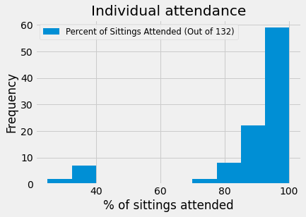

```python
(attendance.drop('Number of Sittings Attended (Out of 132)', axis=1).\
    sort_values('Percent of Sittings Attended (Out of 132)',ascending=False).\
         set_index(['Party', 'Constituency','Name'])).round(2).\
                    plot.hist(bins=10)
plt.xlabel('% of sittings attended'), plt.title('Individual attendance')
plt.legend(fontsize='small')

(attendance.\
    sort_values('Percent of Sittings Attended (Out of 132)',ascending=False).\
         set_index(['Party', 'Constituency','Name'])).round(2).describe().T
```

Highest attendance

```python
(attendance.drop('Number of Sittings Attended (Out of 132)', axis=1).\
    sort_values('Percent of Sittings Attended (Out of 132)',ascending=False).\
         set_index(['Party', 'Constituency','Name'])).round(2).head(10)
```

| Party | Constituency | Name | Percent of Sittings Attended (Out of 132) |
| --- | --- | --- | --- |
| People's Action Party | Holland-Bukit Timah GRC | Christopher De Souza | 100.00 |
|  | Jalan Besar GRC | Denise Phua Lay Peng | 100.00 |
|  | Nee Soon GRC | Louis Ng Kok Kwang | 100.00 |
|  | Tampines GRC | Desmond Choo | 100.00 |
|  | Tanjong Pagar GRC | Melvin Yong Yik Chye | 100.00 |
|  | West Coast GRC | Patrick Tay Teck Guan | 100.00 |
| Workers' Party | Non-Constituency MPs | Dennis Tan Lip Fong | 100.00 |
| People's Action Party | Chua Chu Kang GRC | Low Yen Ling | 99.24 |
|  | Ang Mo Kio GRC | Lee Hsien Loong | 99.24 |
|  | Chua Chu Kang GRC | Yee Chia Hsing | 99.24 |

Lowest attendance

```python
(attendance.drop('Number of Sittings Attended (Out of 132)', axis=1).\
    sort_values('Percent of Sittings Attended (Out of 132)',ascending=False).\
         set_index(['Party', 'Constituency','Name'])).round(2).tail(10)
```

| Party | Constituency | Name | Percent of Sittings Attended (Out of 132) |
| --- | --- | --- | --- |
| People's Action Party | East Coast GRC | Lim Swee Say | 72.73 |
| Nominated MPs | Nominated MPs | Arasu Duraisamy | 37.88 |
|  |  | Mohamed Irshad | 37.88 |
|  |  | Anthea Ong | 37.88 |
|  |  | Terence Ho Wee San | 37.12 |
|  |  | Dr Walter Theseira | 37.12 |
|  |  | Lim Sun Sun | 34.85 |
|  |  | Irene Quay Siew Ching | 32.58 |
|  |  | Douglas Foo | 29.55 |
|  |  | Yip Pin Xiu | 25.00 |

## Speaking

### Speaking by Party

```python
(speaking.groupby('Party')[['Percent of Sittings Spoken (Out of 131)']].mean()).\
    sort_values(['Percent of Sittings Spoken (Out of 131)'],ascending=False).round(2)
```

| Party | Percent of Sittings Spoken (Out of 131) |
| --- | --- |
| Workers' Party | 55.39 |
| People's Action Party | 38.92 |
| Nominated MPs | 16.62 |

### Speaking by Constituency

|  | count | mean | std | min | 25% | 50% | 75% | max |
| --- | --- | --- | --- | --- | --- | --- | --- | --- |
| Percent of Sittings Spoken (Out of 131) | 30.0 | 38.757333 | 13.376417 | 10.69 | 28.055 | 41.22 | 45.495 | 68.96 |

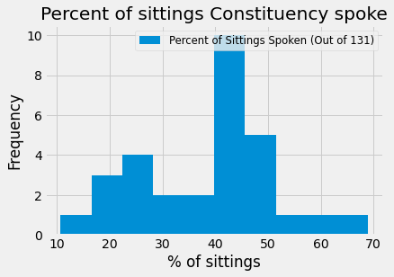

```python
(speaking.groupby(['Constituency','Party'])[['Percent of Sittings Spoken (Out of 131)']].mean())\
                    .sort_values('Percent of Sittings Spoken (Out of 131)',ascending=False).round(2).\
                    plot.hist(bins=10)
plt.xlabel('% of sittings'), plt.title(
    'Percent of sittings Constituency spoke')
plt.legend(fontsize='small')

(speaking.groupby(['Constituency','Party'])[['Percent of Sittings Spoken (Out of 131)']].mean())\
                    .sort_values('Percent of Sittings Spoken (Out of 131)',ascending=False).round(2).\
                    describe().T
```

```python
(speaking.groupby(['Constituency','Party'])[['Percent of Sittings Spoken (Out of 131)']].mean())\
                    .sort_values('Percent of Sittings Spoken (Out of 131)',ascending=False).round(2).head()
```

| Constituency | Party | Percent of Sittings Spoken (Out of 131) |
| --- | --- | --- |
| Non-Constituency MPs | Workers' Party | 68.96 |
| Nee Soon GRC | People's Action Party | 60.50 |
| Bukit Batok SMC | People's Action Party | 54.20 |
| Mountbatten SMC | People's Action Party | 51.15 |
| Tanjong Pagar GRC | People's Action Party | 50.38 |

```python
(speaking.groupby(['Constituency','Party'])[['Percent of Sittings Spoken (Out of 131)']].mean())\
                    .sort_values('Percent of Sittings Spoken (Out of 131)',ascending=False).round(2).tail()
```

| Constituency | Party | Percent of Sittings Spoken (Out of 131) |
| --- | --- | --- |
| Pioneer SMC | People's Action Party | 22.90 |
| Radin Mas SMC | People's Action Party | 22.14 |
| East Coast GRC | People's Action Party | 18.32 |
| Nominated MPs | Nominated MPs | 16.62 |
| Punggol East SMC | People's Action Party | 10.69 |

### Individial number of sittings spoken

|  | count | mean | std | min | 25% | 50% | 75% | max |
| --- | --- | --- | --- | --- | --- | --- | --- | --- |
| Percent of Sittings Spoken (Out of 131) | 80.0 | 38.263125 | 18.383296 | 4.58 | 24.2375 | 40.46 | 49.62 | 87.02 |

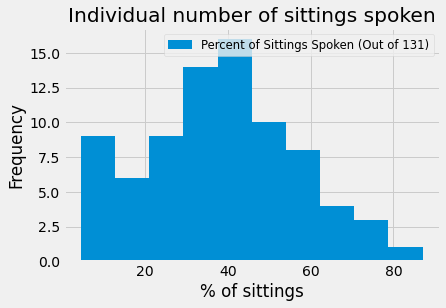

```python
speaking.drop('Number of Sittings Spoken (Out of 131)',axis=1).\
    sort_values('Percent of Sittings Spoken (Out of 131)',ascending=False).\
         set_index(['Party', 'Constituency','Name']).\
                    plot.hist(bins=10)
plt.xlabel('% of sittings'), plt.title('Individual number of sittings spoken')
plt.legend(fontsize='small')

speaking.drop('Number of Sittings Spoken (Out of 131)',axis=1).\
    sort_values('Percent of Sittings Spoken (Out of 131)',ascending=False).\
         set_index(['Party', 'Constituency','Name']).describe().T
```

Spoke the most

```python
speaking.drop('Number of Sittings Spoken (Out of 131)',axis=1).\
    sort_values('Percent of Sittings Spoken (Out of 131)',ascending=False).\
         set_index(['Party', 'Constituency','Name']).head(10)
```

| Party | Constituency | Name | Percent of Sittings Spoken (Out of 131) |
| --- | --- | --- | --- |
| People's Action Party | Nee Soon GRC | Louis Ng Kok Kwang | 87.02 |
| Workers' Party | Non-Constituency MPs | Leon Perera | 75.57 |
|  |  | Dennis Tan Lip Fong | 73.28 |
|  | Aljunied GRC | Pritam Singh | 71.76 |
| People's Action Party | Nee Soon GRC | Lee Bee Wah | 70.23 |
|  | Tanjong Pagar GRC | Joan Pereira | 66.41 |
|  | Ang Mo Kio GRC | Gan Thiam Poh | 65.65 |
| Workers' Party | Aljunied GRC | Sylvia Lim | 62.60 |
| People's Action Party | Tampines GRC | Desmond Choo | 60.31 |
|  | Bishan-Toa Payoh GRC | Saktiandi Supaat | 58.78 |

Spoke the least

```python
speaking.drop('Number of Sittings Spoken (Out of 131)',axis=1).\
    sort_values('Percent of Sittings Spoken (Out of 131)',ascending=False).\
         set_index(['Party', 'Constituency','Name']).tail(10)
```

| Party | Constituency | Name | Percent of Sittings Spoken (Out of 131) |
| --- | --- | --- | --- |
| Nominated MPs | Nominated MPs | Lim Sun Sun | 15.27 |
| People's Action Party | West Coast GRC | Lim Hng Kiang | 10.69 |
| Nominated MPs | Nominated MPs | Terence Ho Wee San | 10.69 |
| People's Action Party | Jalan Besar GRC | Heng Chee How | 10.69 |
|  | Punggol East SMC | Charles Chong | 10.69 |
| Nominated MPs | Nominated MPs | Arasu Duraisamy | 9.16 |
|  |  | Douglas Foo | 9.16 |
| People's Action Party | East Coast GRC | Lee Yi Shyan | 6.11 |
| Nominated MPs | Nominated MPs | Yip Pin Xiu | 6.11 |
| People's Action Party | Pasir Ris-Punggol GRC | Teo Ser Luck | 4.58 |

## Spoke while attending meeting

We might also be interested to know how many times parties spoke while they are present for the meeting

```python
attendance_speaking = pd.merge(
    attendance[[
        'Party', 'Constituency', 'Name',
        'Number of Sittings Attended (Out of 132)'
    ]],
    speaking[['Name', 'Number of Sittings Spoken (Out of 131)']],
    on='Name')
```

```python
attendance_speaking['Spoke per meeting (Out of 131)'] = ((attendance_speaking['Number of Sittings Attended (Out of 132)']-1)\
                                           / attendance_speaking['Number of Sittings Spoken (Out of 131)'])\
                                        .round(2)
```

```python
attendance_speaking = attendance_speaking.drop([
    'Number of Sittings Attended (Out of 132)',
    'Number of Sittings Spoken (Out of 131)'
],axis=1)
```

```python
attendance_speaking.head()
```

|  | Party | Constituency | Name | Spoke per meeting (Out of 131) |
| --- | --- | --- | --- | --- |
| 0 | Workers' Party | Aljunied GRC | Low Thia Khiang | 2.17 |
| 1 | Workers' Party | Aljunied GRC | Pritam Singh | 1.36 |
| 2 | People's Action Party | Holland-Bukit Timah GRC | Christopher De Souza | 1.72 |
| 3 | People's Action Party | Jalan Besar GRC | Denise Phua Lay Peng | 2.43 |
| 4 | People's Action Party | Nee Soon GRC | Louis Ng Kok Kwang | 1.15 |

### Spoke while attending meeting by Party

```python
(attendance_speaking.groupby('Party')[['Spoke per meeting (Out of 131)']].mean() / 131 * 100).\
    sort_values(['Spoke per meeting (Out of 131)'],ascending=False).round(2)
```

| Party | Spoke per meeting (Out of 131) |
| --- | --- |
| People's Action Party | 2.53 |
| Nominated MPs | 1.96 |
| Workers' Party | 1.48 |

### Spoke while attending by Constituency

|  | count | mean | std | min | 25% | 50% | 75% | max |
| --- | --- | --- | --- | --- | --- | --- | --- | --- |
| Spoke per meeting (Out of 131) | 30.0 | 3.110333 | 1.666461 | 1.41 | 2.1425 | 2.45 | 3.8825 | 8.93 |

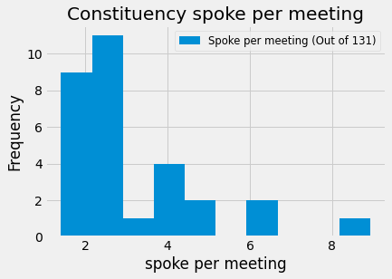

```python
(attendance_speaking.groupby(['Constituency','Party'])[['Spoke per meeting (Out of 131)']].mean())\
                    .sort_values('Spoke per meeting (Out of 131)',ascending=False).round(2).\
                    plot.hist(bins=10)
plt.xlabel('spoke per meeting'), plt.title('Constituency spoke per meeting')
plt.legend(fontsize='small')

(attendance_speaking.groupby(['Constituency','Party'])[['Spoke per meeting (Out of 131)']].mean())\
                    .sort_values('Spoke per meeting (Out of 131)',ascending=False).round(2).\
                    describe().T
```

Constituency that spoke the most during sittings

```python
(attendance_speaking.groupby(['Constituency','Party'])[['Spoke per meeting (Out of 131)']].mean())\
                    .sort_values('Spoke per meeting (Out of 131)',ascending=False).round(2).head()
```

| Constituency | Party | Spoke per meeting (Out of 131) |
| --- | --- | --- |
| Punggol East SMC | People's Action Party | 8.93 |
| East Coast GRC | People's Action Party | 6.51 |
| Pasir Ris-Punggol GRC | People's Action Party | 6.12 |
| Jalan Besar GRC | People's Action Party | 4.60 |
| West Coast GRC | People's Action Party | 4.50 |

Constituency that spoke the least during sittings

```python
(attendance_speaking.groupby(['Constituency','Party'])[['Spoke per meeting (Out of 131)']].mean())\
                    .sort_values('Spoke per meeting (Out of 131)',ascending=False).round(2).tail()
```

| Constituency | Party | Spoke per meeting (Out of 131) |
| --- | --- | --- |
| Jurong GRC | People's Action Party | 1.95 |
| Mountbatten SMC | People's Action Party | 1.93 |
| Nee Soon GRC | People's Action Party | 1.75 |
| Bukit Batok SMC | People's Action Party | 1.54 |
| Non-Constituency MPs | Workers' Party | 1.41 |

### Spoke while attending sittings by individual

|  | count | mean | std | min | 25% | 50% | 75% | max |
| --- | --- | --- | --- | --- | --- | --- | --- | --- |
| Spoke per meeting (Out of 131) | 80.0 | 3.0785 | 2.670466 | 1.15 | 1.9025 | 2.215 | 3.2575 | 18.67 |

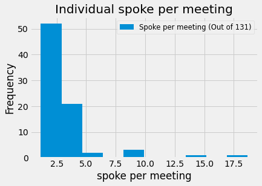

```python
(attendance_speaking[['Party', 'Constituency','Name','Spoke per meeting (Out of 131)']].\
    sort_values('Spoke per meeting (Out of 131)',ascending=False).\
         set_index(['Party', 'Constituency','Name'])).round(2).\
                    plot.hist(bins=10)
plt.xlabel('spoke per meeting'), plt.title('Individual spoke per meeting')
plt.legend(fontsize='small')

(attendance_speaking[['Party', 'Constituency','Name','Spoke per meeting (Out of 131)']].\
    sort_values('Spoke per meeting (Out of 131)',ascending=False).\
         set_index(['Party', 'Constituency','Name'])).round(2).describe().T
```

Individual who spoke the most during their time in parliament sittings

```python
(attendance_speaking[['Party', 'Constituency','Name','Spoke per meeting (Out of 131)']].\
    sort_values('Spoke per meeting (Out of 131)',ascending=False).\
         set_index(['Party', 'Constituency','Name'])).round(2).head(10)
```

| Party | Constituency | Name | Spoke per meeting (Out of 131) |
| --- | --- | --- | --- |
| People's Action Party | Pasir Ris-Punggol GRC | Teo Ser Luck | 18.67 |
|  | East Coast GRC | Lee Yi Shyan | 14.12 |
|  | Jalan Besar GRC | Heng Chee How | 8.93 |
|  | Punggol East SMC | Charles Chong | 8.93 |
|  | West Coast GRC | Lim Hng Kiang | 8.86 |
|  | Marine Parade GRC | Tan Chuan-Jin | 5.81 |
|  | East Coast GRC | Mohamad Maliki Bin Osman | 5.00 |
|  |  | Lim Swee Say | 4.32 |
|  | Holland-Bukit Timah GRC | Sim Ann | 4.17 |
| Nominated MPs | Nominated MPs | Arasu Duraisamy | 4.08 |

Individual who spoke the least during their time in parliament sittings

```python
(attendance_speaking[['Party', 'Constituency','Name','Spoke per meeting (Out of 131)']].\
    sort_values('Spoke per meeting (Out of 131)',ascending=False).\
         set_index(['Party', 'Constituency','Name'])).round(2).tail(10)
```

| Party | Constituency | Name | Spoke per meeting (Out of 131) |
| --- | --- | --- | --- |
| People's Action Party | Bukit Batok SMC | Murali Pillai | 1.54 |
|  | Tanjong Pagar GRC | Joan Pereira | 1.49 |
|  | Ang Mo Kio GRC | Gan Thiam Poh | 1.47 |
|  | Nee Soon GRC | Lee Bee Wah | 1.38 |
| Workers' Party | Non-Constituency MPs | Dennis Tan Lip Fong | 1.36 |
|  | Aljunied GRC | Pritam Singh | 1.36 |
|  | Non-Constituency MPs | Leon Perera | 1.29 |
| Nominated MPs | Nominated MPs | Anthea Ong | 1.17 |
|  |  | Dr Walter Theseira | 1.17 |
| People's Action Party | Nee Soon GRC | Louis Ng Kok Kwang | 1.15 |

# Overall

We will display the full rows here

```python
pd.set_option('display.max_rows', None)
```

## Party performance

```python
party_performance = pd.merge(
    (attendance.groupby('Party')[['Percent of Sittings Attended (Out of 132)'
                                  ]].mean()).round(2).reset_index(),
    pd.merge(
        (speaking.groupby('Party')[['Percent of Sittings Spoken (Out of 131)'
                                    ]].mean()).round(2).reset_index(),
        (attendance_speaking.groupby('Party')[[
            'Spoke per meeting (Out of 131)'
        ]].mean()).round(2).reset_index()))
party_performance = party_performance.set_index('Party')
```

```python
party_performance
```

| Party | Percent of Sittings Attended (Out of 132) | Percent of Sittings Spoken (Out of 131) | Spoke per meeting (Out of 131) |
| --- | --- | --- | --- |
| Nominated MPs | 34.43 | 16.62 | 2.57 |
| People's Action Party | 93.28 | 38.92 | 3.32 |
| Workers' Party | 96.13 | 55.39 | 1.93 |

## Constituency performance

```python
constituency_performance = pd.merge((attendance.groupby(['Constituency','Party'])[['Percent of Sittings Attended (Out of 132)']].mean())\
                    .sort_values('Percent of Sittings Attended (Out of 132)',ascending=False).round(2).reset_index(),
                    pd.merge((speaking.groupby(['Constituency','Party'])[['Percent of Sittings Spoken (Out of 131)']].mean())\
                    .sort_values('Percent of Sittings Spoken (Out of 131)',ascending=False).round(2).reset_index(),
                            (attendance_speaking.groupby(['Constituency','Party'])[['Spoke per meeting (Out of 131)']].mean())\
                    .sort_values('Spoke per meeting (Out of 131)',ascending=False).round(2).reset_index(),
                            on=['Constituency','Party'], how='outer'),on=['Constituency','Party'], how='outer')
constituency_performance = constituency_performance.fillna(0, axis=1).set_index(['Party','Constituency'])
```

```python
constituency_performance
```

| Party | Constituency | Percent of Sittings Attended (Out of 132) | Percent of Sittings Spoken (Out of 131) | Spoke per meeting (Out of 131) |
| --- | --- | --- | --- | --- |
| Workers' Party | Hougang SMC | 98.48 | 45.80 | 2.15 |
| People's Action Party | Mountbatten SMC | 98.48 | 51.15 | 1.93 |
|  | Marsiling-Yew Tee GRC | 97.98 | 38.54 | 2.60 |
|  | Tanjong Pagar GRC | 97.27 | 50.38 | 2.04 |
|  | Potong Pasir SMC | 96.97 | 25.95 | 3.74 |
|  | Chua Chu Kang GRC | 96.97 | 42.49 | 2.36 |
|  | Jalan Besar GRC | 96.78 | 26.91 | 4.60 |
| Workers' Party | Non-Constituency MPs | 96.47 | 68.96 | 1.41 |
| People's Action Party | Ang Mo Kio GRC | 96.08 | 44.58 | 2.33 |
|  | Jurong GRC | 95.76 | 50.13 | 1.95 |
| Workers' Party | Aljunied GRC | 95.45 | 49.16 | 2.21 |
| People's Action Party | Punggol East SMC | 95.45 | 10.69 | 8.93 |
|  | MacPherson SMC | 94.70 | 40.46 | 2.34 |
|  | Holland-Bukit Timah GRC | 94.51 | 43.26 | 2.61 |
|  | Sembawang GRC | 94.09 | 40.46 | 2.37 |
|  | Nee Soon GRC | 93.94 | 60.50 | 1.75 |
|  | Bukit Panjang SMC | 93.18 | 23.66 | 3.94 |
|  | West Coast GRC | 92.61 | 33.84 | 4.50 |
|  | Sengkang West SMC | 92.42 | 41.98 | 2.20 |
|  | Pioneer SMC | 91.67 | 22.90 | 4.00 |
|  | Yuhua SMC | 91.67 | 0.00 | 0.00 |
|  | Fengshan SMC | 91.67 | 42.75 | 2.14 |
|  | Bishan-Toa Payoh GRC | 91.51 | 40.20 | 2.63 |
|  | Tampines GRC | 91.51 | 44.28 | 2.53 |
|  | Marine Parade GRC | 91.06 | 31.49 | 3.29 |
|  | Hong Kah North SMC | 90.91 | 43.51 | 2.09 |
|  | Pasir Ris-Punggol GRC | 90.15 | 37.41 | 6.12 |
|  | Radin Mas SMC | 87.12 | 22.14 | 3.93 |
|  | Bukit Batok SMC | 83.33 | 54.20 | 1.54 |
|  | East Coast GRC | 82.77 | 18.32 | 6.51 |
| Nominated MPs | Nominated MPs | 34.43 | 16.62 | 2.57 |

## Individual performance

```python
individual_performance = pd.merge((attendance.drop('Number of Sittings Attended (Out of 132)', axis=1).\
    sort_values('Percent of Sittings Attended (Out of 132)',ascending=False).\
         set_index(['Party', 'Constituency','Name'])).round(2),
        pd.merge(speaking.drop('Number of Sittings Spoken (Out of 131)',axis=1).\
    sort_values('Percent of Sittings Spoken (Out of 131)',ascending=False).\
         set_index(['Party', 'Constituency','Name']),
                (attendance_speaking[['Party', 'Constituency','Name','Spoke per meeting (Out of 131)']].\
    sort_values('Spoke per meeting (Out of 131)',ascending=False).\
         set_index(['Party', 'Constituency','Name'])).round(2),
                on=['Party','Constituency','Name'], how='outer'), on=['Party','Constituency','Name'], how='outer')
individual_performance = individual_performance.fillna(0, axis=1)
```

```python
individual_performance
```

| Party | Constituency | Name | Percent of Sittings Attended (Out of 132) | Percent of Sittings Spoken (Out of 131) | Spoke per meeting (Out of 131) |
| --- | --- | --- | --- | --- | --- |
| People's Action Party | Holland-Bukit Timah GRC | Christopher De Souza | 100.00 | 58.02 | 1.72 |
|  | Jalan Besar GRC | Denise Phua Lay Peng | 100.00 | 41.22 | 2.43 |
|  | Nee Soon GRC | Louis Ng Kok Kwang | 100.00 | 87.02 | 1.15 |
|  | Tampines GRC | Desmond Choo | 100.00 | 60.31 | 1.66 |
|  | Tanjong Pagar GRC | Melvin Yong Yik Chye | 100.00 | 49.62 | 2.02 |
|  | West Coast GRC | Patrick Tay Teck Guan | 100.00 | 58.02 | 1.72 |
| Workers' Party | Non-Constituency MPs | Dennis Tan Lip Fong | 100.00 | 73.28 | 1.36 |
| People's Action Party | Chua Chu Kang GRC | Low Yen Ling | 99.24 | 33.59 | 2.95 |
|  | Ang Mo Kio GRC | Lee Hsien Loong | 99.24 | 0.00 | 0.00 |
|  | Chua Chu Kang GRC | Yee Chia Hsing | 99.24 | 44.27 | 2.24 |
|  | Tanjong Pagar GRC | Joan Pereira | 99.24 | 66.41 | 1.49 |
|  | Marine Parade GRC | Goh Chok Tong | 98.48 | 0.00 | 0.00 |
|  | Marsiling-Yew Tee GRC | Lawrence Wong | 98.48 | 0.00 | 0.00 |
|  |  | Ong Teng Koon | 98.48 | 32.82 | 3.00 |
|  | Mountbatten SMC | Lim Biow Chuan | 98.48 | 51.15 | 1.93 |
| Workers' Party | Hougang SMC | Png Eng Huat | 98.48 | 45.80 | 2.15 |
| People's Action Party | Ang Mo Kio GRC | Ang Hin Kee | 98.48 | 37.40 | 2.63 |
|  | Jurong GRC | Rahayu Mahzam | 97.73 | 55.73 | 1.75 |
| Workers' Party | Non-Constituency MPs | Leon Perera | 97.73 | 75.57 | 1.29 |
| People's Action Party | Tanjong Pagar GRC | Chan Chun Sing | 97.73 | 0.00 | 0.00 |
| Workers' Party | Aljunied GRC | Pritam Singh | 97.73 | 71.76 | 1.36 |
| People's Action Party | Bishan-Toa Payoh GRC | Chong Kee Hiong | 97.73 | 30.53 | 3.20 |
|  | Tanjong Pagar GRC | Indranee Rajah | 97.73 | 0.00 | 0.00 |
| Workers' Party | Aljunied GRC | Sylvia Lim | 96.97 | 62.60 | 1.55 |
| People's Action Party | Holland-Bukit Timah GRC | Liang Eng Hwa | 96.97 | 49.62 | 1.95 |
|  | Jurong GRC | Ang Wei Neng | 96.97 | 50.38 | 1.92 |
|  |  | Desmond Lee | 96.97 | 0.00 | 0.00 |
|  |  | Tan Wu Meng | 96.97 | 44.27 | 2.19 |
|  | Marsiling-Yew Tee GRC | Alex Yam Ziming | 96.97 | 44.27 | 2.19 |
|  | Nee Soon GRC | Dr Muhammad Faishal Ibrahim | 96.97 | 41.22 | 2.35 |

[output cut: 70 more lines]

## Dashboard

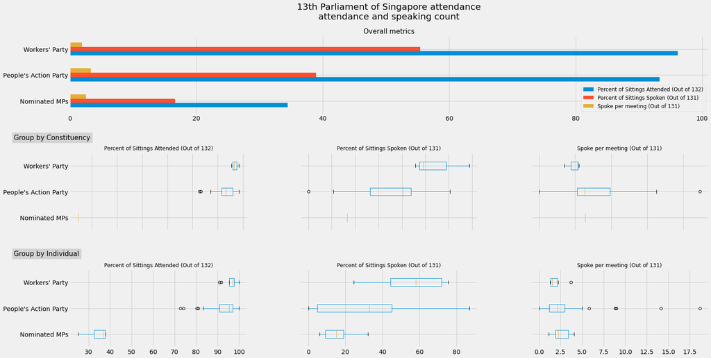

```python
fig = plt.figure(figsize=(25,13))
gs = fig.add_gridspec(3,3, hspace=0.5, wspace=0.3)
ax1 = fig.add_subplot(gs[0,0:])
ax2 = fig.add_subplot(gs[1,0])
ax3 = fig.add_subplot(gs[1,1])
ax4 = fig.add_subplot(gs[1,2])
ax5 = fig.add_subplot(gs[2,0])
ax6 = fig.add_subplot(gs[2,1])
ax7 = fig.add_subplot(gs[2,2])

party_performance.plot(kind='barh', ax=ax1);
pd.plotting.boxplot(constituency_performance.drop(['Percent of Sittings Spoken (Out of 131)',
       'Spoke per meeting (Out of 131)'], axis=1), vert=False, by='Party', ax=ax2);
pd.plotting.boxplot(constituency_performance.drop(['Percent of Sittings Attended (Out of 132)',
       'Spoke per meeting (Out of 131)'], axis=1), vert=False, by='Party', ax=ax3);
pd.plotting.boxplot(constituency_performance.drop(['Percent of Sittings Attended (Out of 132)',
       'Percent of Sittings Spoken (Out of 131)'], axis=1), vert=False, by='Party', ax=ax4);
pd.plotting.boxplot(individual_performance.drop(['Percent of Sittings Spoken (Out of 131)',
       'Spoke per meeting (Out of 131)'], axis=1), vert=False, by='Party', ax=ax5);
pd.plotting.boxplot(individual_performance.drop(['Percent of Sittings Attended (Out of 132)',
       'Spoke per meeting (Out of 131)'], axis=1), vert=False, by='Party', ax=ax6);
pd.plotting.boxplot(individual_performance.drop(['Percent of Sittings Attended (Out of 132)',
       'Percent of Sittings Spoken (Out of 131)'], axis=1), vert=False, by='Party', ax=ax7);

for ax in [ax2, ax3, ax4, ax5, ax6, ax7]:
    ax.set_xlabel(None)
    ax.label_outer()
    ax.set_title(label=ax.title._text,fontsize=12)

fig.suptitle('13th Parliament of Singapore attendance\nattendance and speaking count', fontsize=20)
ax1.set_title('Overall metrics', fontsize=15), ax1.set_ylabel(None), ax1.legend(fontsize='small')
fig.text(0.03, 0.65, 'Group by Constituency', fontsize=15, backgroundcolor='lightgrey')
fig.text(0.03, 0.37, 'Group by Individual', fontsize=15, backgroundcolor='lightgrey');

fig.savefig('output/dashboard.png')
```

# Remarks

We note that cabinet members do not speak in sittings. Perhaps it's because parliament is an opporunity to hear alternate views on the bills been presented. But I'm not sure about the details of parliament sittings.\ As a result of the cabinet members, PAP's speaking percentage is an underestimated performance of the party.

```python
individual_performance[(individual_performance['Spoke per meeting (Out of 131)'] == 0)]
```

| Party | Constituency | Name | Percent of Sittings Attended (Out of 132) | Percent of Sittings Spoken (Out of 131) | Spoke per meeting (Out of 131) |
| --- | --- | --- | --- | --- | --- |
| People's Action Party | Ang Mo Kio GRC | Lee Hsien Loong | 99.24 | 0.0 | 0.0 |
|  | Marine Parade GRC | Goh Chok Tong | 98.48 | 0.0 | 0.0 |
|  | Marsiling-Yew Tee GRC | Lawrence Wong | 98.48 | 0.0 | 0.0 |
|  | Tanjong Pagar GRC | Chan Chun Sing | 97.73 | 0.0 | 0.0 |
|  |  | Indranee Rajah | 97.73 | 0.0 | 0.0 |
|  | Jurong GRC | Desmond Lee | 96.97 | 0.0 | 0.0 |
|  | Chua Chu Kang GRC | Gan Kim Yong | 96.21 | 0.0 | 0.0 |
|  | Sembawang GRC | Ong Ye Kung | 93.94 | 0.0 | 0.0 |
|  | Yuhua SMC | Grace Fu Hai Yien | 91.67 | 0.0 | 0.0 |
|  | Jurong GRC | Tharman Shanmugaratnam | 90.15 | 0.0 | 0.0 |
|  | Sembawang GRC | Khaw Boon Wan | 90.15 | 0.0 | 0.0 |
|  | Pasir Ris-Punggol GRC | Ng Chee Meng | 89.39 | 0.0 | 0.0 |
|  |  | Teo Chee Hean | 89.39 | 0.0 | 0.0 |
|  | Holland-Bukit Timah GRC | Vivian Balakrishnan | 88.64 | 0.0 | 0.0 |
|  | Bishan-Toa Payoh GRC | Josephine Teo | 84.09 | 0.0 | 0.0 |
|  |  | Ng Eng Hen | 84.09 | 0.0 | 0.0 |
|  | Tampines GRC | Heng Swee Keat | 84.09 | 0.0 | 0.0 |
|  | Nee Soon GRC | K Shanmugam | 83.33 | 0.0 | 0.0 |
|  | Tampines GRC | Masagos Zulkifli Bin Masagos Mohamad | 81.06 | 0.0 | 0.0 |
|  | West Coast GRC | S Iswaran | 80.30 | 0.0 | 0.0 |

```python
pd.set_option('display.max_rows', 10)
```